# Nonparametric Homework 6

Brad Hughes

4/8/2020

```r
library(dplyr)
school = read.csv("C:/Users/Brad/Documents/Classes/Stat488_nonpara/ill_school_data.csv", header = T)
attach(school)
```

Everyone in this data set is an Illinois, high school student. The 99 year old in the data set is either an alien or a sample observation that was not removed. This person has a height of 999cm, a reaction time of 0.002 (milliseconds?), knows 7 languages, and is in 10th grade. I’m convinced this is a protagonist to an anime. There are a bunch of other large numbers where they shouldn’t be, such as a foot length of 97cm is probably supposed to be 9.7cm or the arm span of ‘idk’. I really want to know where in Illinois it is possible to travel to school in a boat. The importance stats appear to range from 0-1000 but some people felt more passionate with scores of 9000. A lot of students are missing the favorite _____ categories.

```r
school %>% select(Handed, Favorite_Season) %>% group_by(Handed, Favorite_Season) %>% count()
```

```
## # A tibble: 17 x 3
## # Groups:   Handed, Favorite_Season [17]
##    Handed         Favorite_Season     n
##    <fct>          <fct>           <int>
##  1 ""             ""                 11
##  2 ""             "Summer"            1
##  3 "Ambidextrous" ""                  3
##  4 "Ambidextrous" "Fall"              7
##  5 "Ambidextrous" "Spring"            2
##  6 "Ambidextrous" "Summer"            4
##  7 "Ambidextrous" "Winter"            3
##  8 "Left-Handed"  ""                  3
##  9 "Left-Handed"  "Fall"             14
## 10 "Left-Handed"  "Spring"            8
## 11 "Left-Handed"  "Summer"           17
## 12 "Left-Handed"  "Winter"            5
## 13 "Right-Handed" ""                 33
## 14 "Right-Handed" "Fall"            157
## 15 "Right-Handed" "Spring"           47
## 16 "Right-Handed" "Summer"          146
## 17 "Right-Handed" "Winter"           39
```

I think it is probably fine to remove the blanks associated with Handed and Favorite_season in this case. There are 51 observations missing one of or both values which is 10% of our total data. The amount of our missing data is still small enough and we also still have a very large sample of 450 where it will probably be alright.

```r
hand_season = school %>% select(Handed, Favorite_Season)
hand_season = hand_season[!(hand_season$Handed=="" | hand_season$Favorite_Season == ""),]
hand_season$Handed = droplevels(hand_season$Handed, exclude = "")
hand_season$Favorite_Season = droplevels(hand_season$Favorite_Season, exclude = "")
table(hand_season)
```

```
##               Favorite_Season
## Handed         Fall Spring Summer Winter
##   Ambidextrous    7      2      4      3
##   Left-Handed    14      8     17      5
##   Right-Handed  157     47    146     39
```

```r
chisqobs = chisq.test(table(hand_season))$statistic;chisqobs
```

```
## X-squared
##  3.788089
```

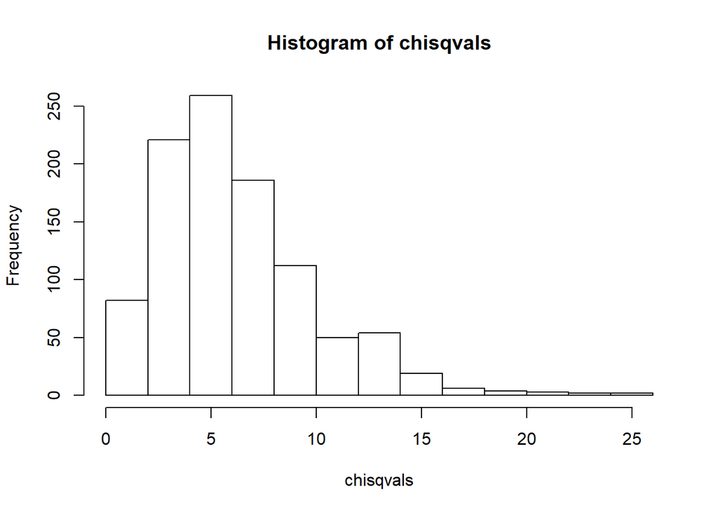

```r
set.seed(42)
nsim = 1000
chisqvals = rep(NA,nsim)
for (i in 1:nsim) {
  dataTemp = hand_season
  dataTemp$Handed = dataTemp$Handed[sample(1:449,449)]
  chisqvals[i] = chisq.test(table(dataTemp))$statistic
}
hist(chisqvals)
```

```r
sum(chisqvals > chisqobs)/nsim
```

```
## [1] 0.721
```

```r
detach(school)
```

Assuming that the two variables of dominant hand and favorite season are independent I decided to run a permutation test to test the alternative hypothesis that the 2 variables are not independent. With alpha=0.05 I obtained a p-value of 0.721 which is much higher than our critical alpha so we failed in showing any dependence of the 2 variables. I chose this test because it’s a nonparametric class. Permutation tests work under the assumption that the variables are indepedent and all of our observations are randomly selected.

```r
library(readr)
HAdata = school %>% select(Height_cm, Armspan_cm, Ageyears, Footlength_cm, Index_Fingerlength_mm, Ring_Fingerlength_mm)
HAdata = sapply(HAdata, as.character)
for (i in 1:6) {
  HAdata[,i] = parse_number(HAdata[,i], na=c("", "NA", "idk"))
}
HAdata = as.data.frame(HAdata)
for (i in 1:6) {
  HAdata[,i] = as.numeric(as.character(HAdata[,i]))
}
attach(HAdata)
HAdata$Height_cm = ifelse(Height_cm > 201, NA, ifelse(Height_cm < 2, Height_cm*100, ifelse(Height_cm < 9, Height_cm*10+100, ifelse(Height_cm < 100, Height_cm+100, Height_cm))))
HAdata$Armspan_cm = ifelse(Armspan_cm < 2, Armspan_cm*100, ifelse(Armspan_cm < 100, Armspan_cm+100, ifelse(Armspan_cm > 400, NA, Armspan_cm)))
HAdata$Ageyears = ifelse(Ageyears > 20, NA, Ageyears)
HAdata$Footlength_cm = ifelse(Footlength_cm > 55, NA, ifelse(Footlength_cm < 10, Footlength_cm+10, Footlength_cm))
HAdata$Index_Fingerlength_mm = ifelse(Index_Fingerlength_mm > 120, NA, ifelse(Index_Fingerlength_mm <= 30, NA, Index_Fingerlength_mm))
HAdata$Ring_Fingerlength_mm = ifelse(Ring_Fingerlength_mm > 120, NA, ifelse(Ring_Fingerlength_mm <= 30, NA, Ring_Fingerlength_mm))
detach(HAdata)
```

```r
library(mice)
imps = mice(HAdata, m=5, method="cart")
impslist = list()
impslist[[1]] = complete(imps)
impslist[[2]] = complete(imps,2)
impslist[[3]] = complete(imps,3)
impslist[[4]] = complete(imps,4)
impslist[[5]] = complete(imps,5)

betaList<-seList<-list()
for (i in 1:5) {
  betaList[[i]]<-summary(lm(Height_cm~Armspan_cm, data = as.data.frame(impslist[[i]])))$coefficients[,1]
  seList[[i]]<-summary(lm(Height_cm~Armspan_cm, data = as.data.frame(impslist[[i]])))$coefficients[,2]
}

M=5
apply(do.call(rbind,betaList),2,mean)
```

```
## (Intercept)  Armspan_cm
##  94.0579243   0.4447999
```

```r
B<-apply(do.call(rbind,betaList),2,var)
W<-apply(do.call(rbind,seList)^2,2,mean)
T<-(1+1/M)*B + W
sqrt(T)
```

```
## (Intercept)  Armspan_cm
##  4.89295596  0.02940884
```

The final model is Height=94.06+0.44*Armspan with respective SE’s of 4.89 and 0.03.

```r
imps_rf = mice(HAdata, m=5, method="rf")
impslist_rf = list()
impslist_rf[[1]] = complete(imps_rf)
impslist_rf[[2]] = complete(imps_rf,2)
impslist_rf[[3]] = complete(imps_rf,3)
impslist_rf[[4]] = complete(imps_rf,4)
impslist_rf[[5]] = complete(imps_rf,5)

betaList_rf<-seList_rf<-list()
for (i in 1:5) {
  betaList_rf[[i]]<-summary(lm(Height_cm~Armspan_cm, data = as.data.frame(impslist_rf[[i]])))$coefficients[,1]
  seList_rf[[i]]<-summary(lm(Height_cm~Armspan_cm, data = as.data.frame(impslist_rf[[i]])))$coefficients[,2]
}

M=5
apply(do.call(rbind,betaList_rf),2,mean)
```

```
## (Intercept)  Armspan_cm
##  98.1237964   0.4195429
```

```r
B_rf<-apply(do.call(rbind,betaList_rf),2,var)
W_rf<-apply(do.call(rbind,seList_rf)^2,2,mean)
T_rf<-(1+1/M)*B_rf + W_rf
sqrt(T_rf)
```

```
## (Intercept)  Armspan_cm
##  4.97920291  0.02996531
```

This model is Height=98.12+0.42*Armspan with respective SE’s of 4.98 and 0.03.

## Github Link

https://github.com/BradHughes91/Non_Parametric